# My analysis on YouTube videos

Deasy Lie

## Youtube Thumbnail Analysis

I am looking to analyse the obtained data from my google form to see whether certain features of a YouTube thumbnail will affect my likeliness to watch and the appeal of the YouTube video. Additionally I will be looking at the affect of video duration on my likeliness to watch a video as well.

## First Plot

My first plot is used to determine if duration of a YouTube video affects my likeliness to watch the video.

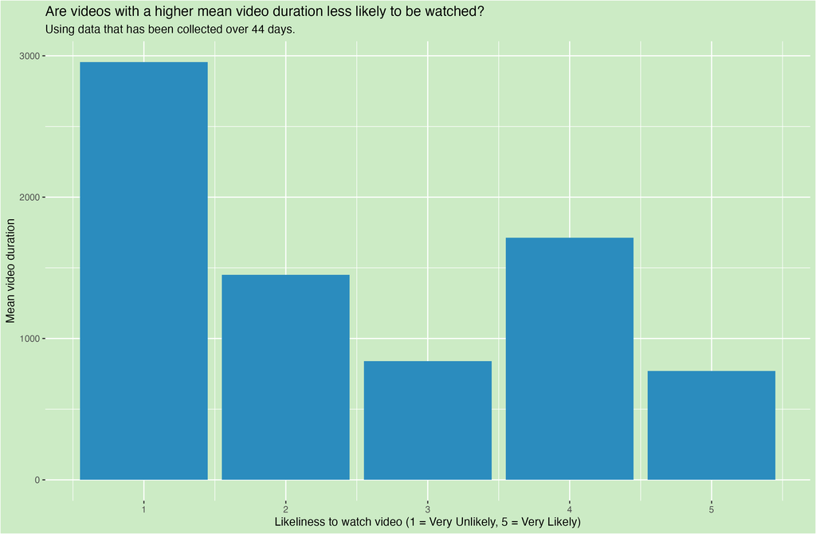

This plot tells me that I am more likely to watch YouTube videos with a shorter duration and least likely to watch YouTube videos that have longer video durations.

Longer videos tend to decrease my likeliness to watch the video however we can see that for a rating of 4 the video duration is higher than for a rating of 3.

## Second Plot

My second plot is used to see if my likeliness to watch a YouTube video depends on the genre of the video.

Video genres include: Entertainment, Music, Gaming and Educational.

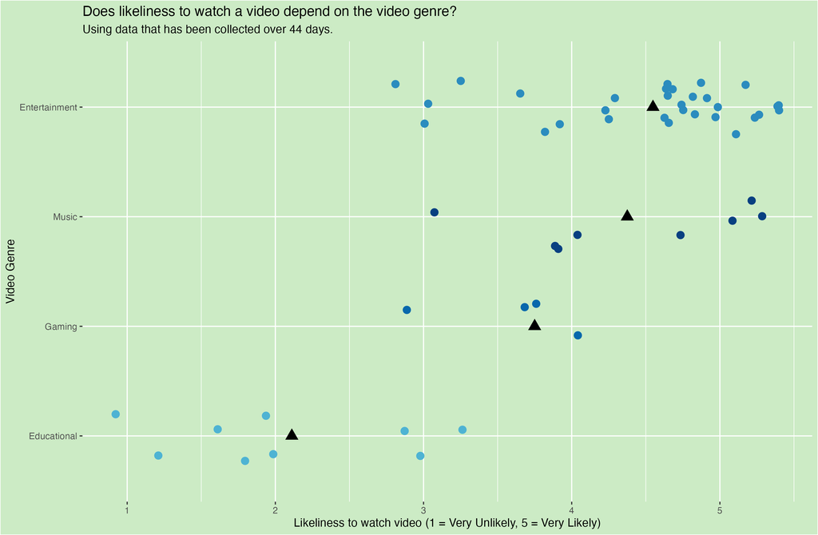

We can see from our plot that the mean likeliness of me watching a YouTube video is higher for the ‘Entertainment’ genre and lowest for ‘Educational’ genre.

## Third Plot

My last plot is used to look at whether thumbnails are most likely to contain more images, more text or be balanced. We should typically get a higher count of thumbnails that are image-heavy.

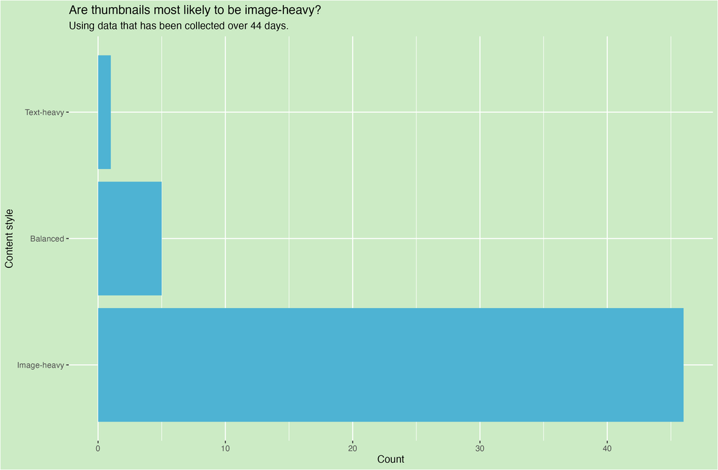

Thumbnails are very likely to contain more images that text. This is as expected as thumbnails are normally image-heavy to attract attention to the video so people are more likely to watch the video through a good image-heavy thumbnail.